# Análisis Descriptivo

En el presenten análisis se describirán algunas variables de la base de datos de siniestros en el Ecuador de los años correspondientes entre Enero 2017 y Diciembre 2022.

```r
df <- read.csv("./BDD_DICIEMBRE_2022.csv")
head(df)
```

|  | X | ID | ANIO | SINIESTROS | LESIONADOS | FALLECIDOS | ENTE_DE_CONTROL | LATITUD_Y | LONGITUD_X | DPA_1 | PROVINCIA | DPA_2 | CANTON | DPA_3 | PARROQUIA | DIRECCION | ZONA_PLANIFICACION | ZONA | ID_DE_LA_VIA | NOMBRE_DE_LA_VIA | UBICACION_DE_LA_VIA | JERARQUIA_DE_LA_VIA | FECHA | HORA | PERIODO_1 | PERIODO_2 | DIA_1 | DIA_2 | MES_1 | … |
| --- | --- | --- | --- | --- | --- | --- | --- | --- | --- | --- | --- | --- | --- | --- | --- | --- | --- | --- | --- | --- | --- | --- | --- | --- | --- | --- | --- | --- | --- | --- |
| 1 | 1 | 1 | 2017 | DMQ00001012017 | 1 | 0 | DMQ | -0.083501 | -78.41774 | 17 | PICHINCHA | 1701 | QUITO | 170155 | CALDERON (CARAPUNGO) | GIOVANNI CALLES & RAFAEL CALVACHE | ZONA 9 | RURAL | ND | ND | ND | ND | 01/01/2017 | 00:15:00 | DE 00H00 A 00H59 | 0 | DOMINGO | 7 | ENERO | … |
| 2 | 2 | 2 | 2017 | ATM00002012017 | 1 | 0 | ATM | -2.246682 | -79.89775 | 9 | GUAYAS | 901 | GUAYAQUIL | 90150 | GUAYAQUIL | CALLE PUYO Y CALLE BAEZA, CDLA. LOS ESTEROS | ZONA 8 | URBANA | ND | ND | ND | ND | 01/01/2017 | 00:25:00 | DE 00H00 A 00H59 | 0 | DOMINGO | 7 | ENERO | … |
| 3 | 3 | 3 | 2017 | PNE00003012017 | 1 | 0 | PNE | -0.253881 | -79.21740 | 23 | SANTO DOMINGO DE LOS TSACHILAS | 2301 | SANTO DOMINGO | 230150 | SANTO DOMINGO DE LOS COLORADOS | COOP. LUZ DEL DIA | ZONA 4 | URBANA | ND | ND | ND | ND | 01/01/2017 | 00:25:00 | DE 00H00 A 00H59 | 0 | DOMINGO | 7 | ENERO | … |
| 4 | 4 | 4 | 2017 | DMQ00004012017 | 0 | 0 | DMQ | -0.116059 | -78.46419 | 17 | PICHINCHA | 1701 | QUITO | 170150 | QUITO | EUGENIO DELGADO Y CARLOS FORTINEZ | ZONA 9 | RURAL | ND | ND | ND | ND | 01/01/2017 | 00:25:00 | DE 00H00 A 00H59 | 0 | DOMINGO | 7 | ENERO | … |
| 5 | 5 | 5 | 2017 | DMQ00005012017 | 0 | 0 | DMQ | -0.239721 | -78.51206 | 17 | PICHINCHA | 1701 | QUITO | 170150 | QUITO | GUAYABAMBA Y CHAMBO | ZONA 9 | URBANA | ND | ND | ND | ND | 01/01/2017 | 00:30:00 | DE 00H00 A 00H59 | 0 | DOMINGO | 7 | ENERO | … |
| 6 | 6 | 6 | 2017 | DMQ00006012017 | 0 | 0 | DMQ | -0.116354 | -78.46504 | 17 | PICHINCHA | 1701 | QUITO | 170150 | QUITO | CALDAS Y RIOS | ZONA 9 | URBANA | ND | ND | ND | ND | 01/01/2017 | 00:30:00 | DE 00H00 A 00H59 | 0 | DOMINGO | 7 | ENERO | … |

```r
table(sapply(df, class))
```

```
character   integer   numeric
       29        26         2
```

```r
# para gráficos
library(ggplot2)
```

## Fallecidos y Lesionados

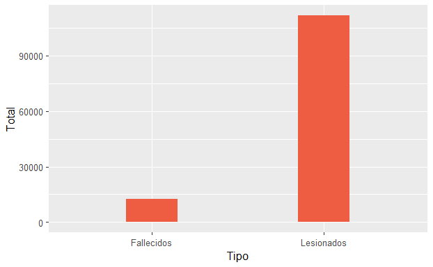

```r
datos_les_fal <- data.frame(Tipo=c("Lesionados", "Fallecidos"),
                            Total=c(sum(df$LESIONADOS),sum(df$FALLECIDOS)))

ggplot(data = datos_les_fal)+
  geom_bar(aes(x=Tipo, y=Total),
               stat ="identity",
               width = 0.3,
               fill = "tomato2")
```

Entreo los años de 2017 y 2022 se resgistraron un total de 111512 lesionados y 12408 fallecidos en los siniestros del Ecuador.

## Ubicación geográfica

[figure not shown]

Se puede observar que las provincias que más registran siniestros son Guayas y Pichincha. Por el otro lado, Galápagos casi no resgistra accidentes.

```r
freq_zona <- data.frame(table(df$ZONA_PLANIFICACION))
colnames(freq_zona) <- c("Zona", "Total")

freq_zona$Zona <- factor(freq_zona$Zona, levels = freq_zona$Zona[order(freq_zona$Zona)])

ggplot(data = freq_zona, aes(y=Total, x=Zona))+
  geom_bar(stat = "identity",
           fill = "olivedrab2")
```

[output not shown]

| zonas | idk |
| --- | --- |
| ZONA 1 | Esmeraldas, Imbabura, Carchi, Sucumbíos |
| ZONA 2 | Pichincha, Napo, Orellana |
| ZONA 3 | Cotopaxi, Tungurahua, Chimborazo, Pastaza |
| ZONA 4 | Manabí, Santo Domingo de los Tsáchilas |
| ZONA 5 | Santa Elena, Guayasm Bolívar, Los Ríos, Galápagos |
| ZONA 6 | Cañar, Azuay, Morona Santiago |
| ZONA 7 | El Oro, Loja, Zamora Chinchipe |
| ZONA 8 | Guayaquil, Samborondón, Durán |
| ZONA 9 | Distrito Metropolitano de Quito |

## Entes de tránsito

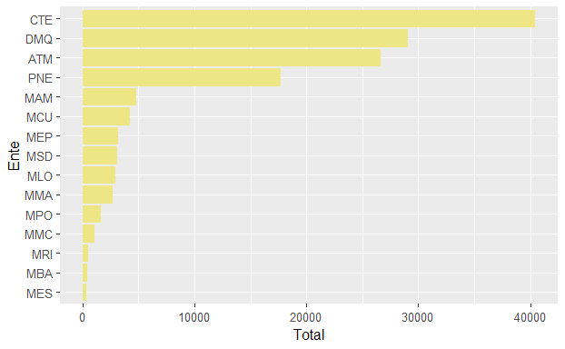

```r
freq_ente_cont <- data.frame(table(df$ENTE_DE_CONTROL))
colnames(freq_ente_cont) <- c("Ente", "Total")

freq_ente_cont$Ente <- factor(freq_ente_cont$Ente, levels = freq_ente_cont$Ente[order(freq_ente_cont$Total)])

ggplot(data = freq_ente_cont, aes(y=Ente, x=Total))+
  geom_bar(stat = "identity",
           fill = "khaki2")
```

Del gráfico se observa que los entes que registran un mayor número de siniestro son CTE, DMQ, ATM y PNE

## Análisis descriptivo - variables de tiempo

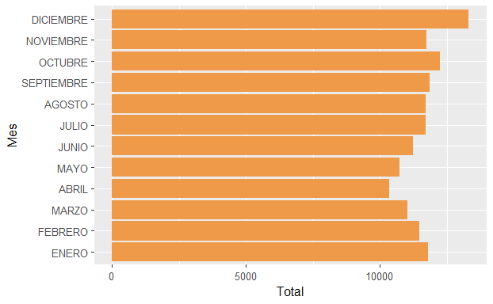

Se observa que no hay una gran diferencia de la cantidad de siniestros entre los meses. Diciembre es el mes que registra más accidentes.

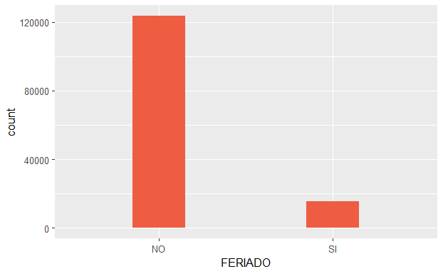

```r
ggplot(data = df, aes(x=FERIADO))+
  geom_bar(
    width = 0.3,
    fill = "tomato2"
  )
```

## Posibles causas, tipos de siniestros

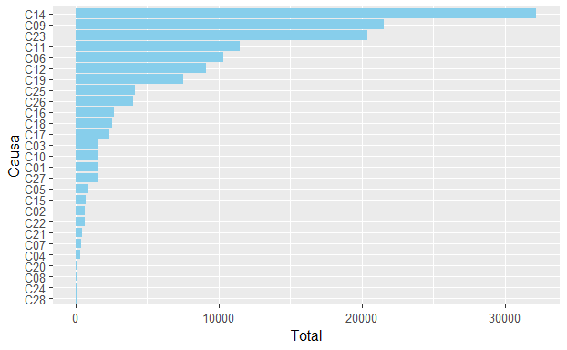

Los códigos de causa

**C14** : Conducir desatento a las condiciones de tránsito (Celular, pantallas de video, comida, maquillaje o cualquier otro elemento distractor).

**C09** : Conducir vehículo superando los límites máximos de velocidad.

**C23** : No respetar las señales reglamentarias de tránsito (pare, ceda el paso, luz roja del semáforo, etc)

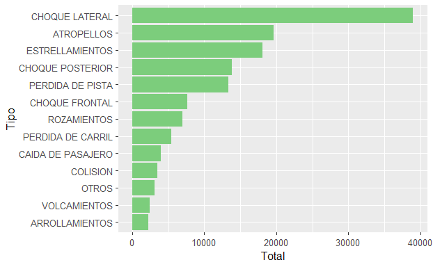

```r
freq_tipo <- data.frame(table(df$TIPO_DE_SINIESTRO))
colnames(freq_tipo) <- c("Tipo", "Total")

freq_tipo$Tipo <- factor(freq_tipo$Tipo, levels = freq_tipo$Tipo[order(freq_tipo$Total)])

ggplot(data = freq_tipo, aes(y=Tipo,x=Total))+
  geom_bar(
    stat = "identity",
    fill = "palegreen3")
```

El choque lateral es el tipo de siniestro más común. Seguido de atropellos y estrellamientos.

## Características del vehículo o vehículos involucrados

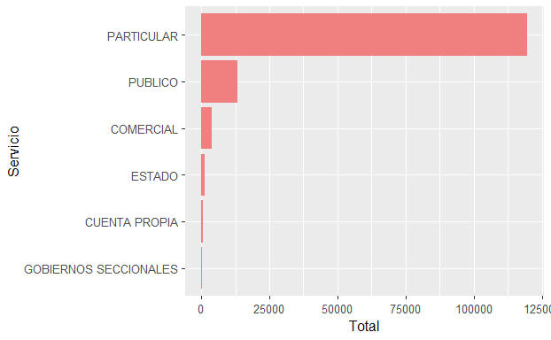

```r
freq_servicio <- data.frame(table(df$SERVICIO_1))
colnames(freq_servicio) <- c("Servicio", "Total")

freq_servicio$Servicio <- factor(freq_servicio$Servicio, levels = freq_servicio$Servicio[order(freq_servicio$Total)])

ggplot(data = freq_servicio, aes(y=Servicio,x=Total))+
  geom_bar(
    stat = "identity",
    fill = "lightcoral")
```

La gran mayoría ocurre en servicios particulares

## Características de las personas involucradas

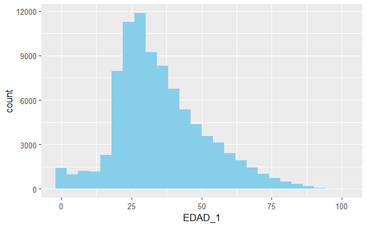

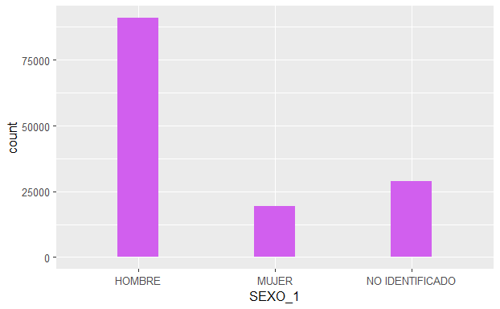

```r
ggplot(data = df, aes(x=SEXO_1))+
  geom_bar(
    width = 0.3,
    fill = "mediumorchid2"
  )
```

Los hombres se involucran mayormente en los siniestros.

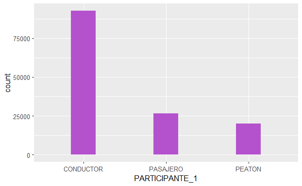

```r
ggplot(data = df, aes(x=PARTICIPANTE_1))+
  geom_bar(
    width = 0.3,
    fill = "mediumorchid3"
  )
```

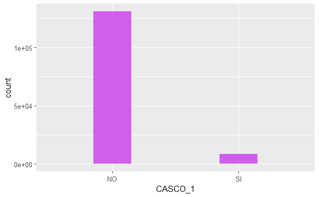

```r
ggplot(data = df, aes(x=CASCO_1))+
  geom_bar(
    width = 0.3,
    fill = "mediumorchid2"
  )
```

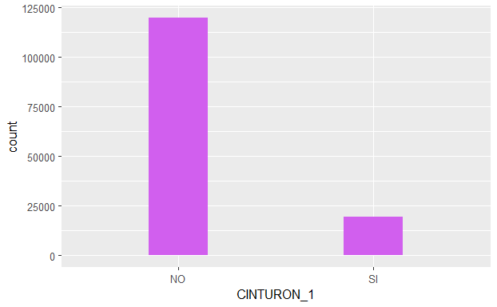

```r
ggplot(data = df, aes(x=CINTURON_1))+
  geom_bar(
    width = 0.3,
    fill = "mediumorchid2"
  )
```